# Mid-term: Hotel booking Data

Eunsun Yook

2020-11-05

## Classification of Hotel Booking Cancellation

### Introduction

Hotel reservation cancellation is unavoidable but one of the major challenges in Hospitality industry because it directly affects a hotel’s profit margins. If a predictive model of cancellation is available in revenue management, it allows hotel managers to develop better cancellation policy, to predict demand accurately, to take actions proactively managing man-hours and resources accordingly, and to make those canceled rooms available for walk-ins or last minute bookings.

This data is extracted from Hotel Profit Management System (PMS) and it contains booking information due to arrive between 7/1/2015 and 8/31/2017 from one resort hotel and one city hotel located in Portugal.

In this project, my goal is to develop a prediction model for classification of bookings with and without cancellation using data mining algorithms.

### Packages Required

Below is the list of packages used in the project.

```r
library(magrittr)
library(tidyverse)
library(car)
library(knitr)
library(psych)
```

- Package `magrittr` is for running tidyverse without error message.
- Package `tidyverse` is used for dplyr for data manipulation and ggplot2 package for creating plots all at once.
- Package `car` is used for identifying outliers in a boxplot.
- Package `knitr` is for displaying tables.
- Package `psych` is for creating multiple histogram.

### Data Preparation

The data was obtained at [tidytuesday](https://github.com/rfordatascience/tidytuesday/blob/master/data/2020/2020-02-11/readme.md) and detailed information can be found in the original publication ([Nuno Antonio, Ana de Almeida, Luis Nunes, 2019](https://www.sciencedirect.com/science/article/pii/S2352340918315191)). Since it is uncommon to find real business data, the authors intended to provide the hotel demand data to researchers and educators in revenue management, machine learning or data mining.

#### Import Data

There are 119390 observation and 32 variables in `hotels.csv` file.

```r
# Importing .csv files
hotels <- read.csv("data/hotels.csv")
# View the structure of hotels
str(hotels)
```

```
## 'data.frame':    119390 obs. of  32 variables:
##  $ hotel                         : chr  "Resort Hotel" "Resort Hotel" "Resort Hotel" "Resort Hotel" ...
##  $ is_canceled                   : int  0 0 0 0 0 0 0 0 1 1 ...
##  $ lead_time                     : int  342 737 7 13 14 14 0 9 85 75 ...
##  $ arrival_date_year             : int  2015 2015 2015 2015 2015 2015 2015 2015 2015 2015 ...
##  $ arrival_date_month            : chr  "July" "July" "July" "July" ...
##  $ arrival_date_week_number      : int  27 27 27 27 27 27 27 27 27 27 ...
##  $ arrival_date_day_of_month     : int  1 1 1 1 1 1 1 1 1 1 ...
##  $ stays_in_weekend_nights       : int  0 0 0 0 0 0 0 0 0 0 ...
##  $ stays_in_week_nights          : int  0 0 1 1 2 2 2 2 3 3 ...
##  $ adults                        : int  2 2 1 1 2 2 2 2 2 2 ...
##  $ children                      : int  0 0 0 0 0 0 0 0 0 0 ...
##  $ babies                        : int  0 0 0 0 0 0 0 0 0 0 ...
##  $ meal                          : chr  "BB" "BB" "BB" "BB" ...
##  $ country                       : chr  "PRT" "PRT" "GBR" "GBR" ...
```

[output cut: 18 more lines]

```r
# View the first 6 rows of hotels
head(hotels)
```

```
##          hotel is_canceled lead_time arrival_date_year arrival_date_month
## 1 Resort Hotel           0       342              2015               July
## 2 Resort Hotel           0       737              2015               July
## 3 Resort Hotel           0         7              2015               July
## 4 Resort Hotel           0        13              2015               July
## 5 Resort Hotel           0        14              2015               July
## 6 Resort Hotel           0        14              2015               July
##   arrival_date_week_number arrival_date_day_of_month stays_in_weekend_nights
## 1                       27                         1                       0
## 2                       27                         1                       0
## 3                       27                         1                       0
## 4                       27                         1                       0
## 5                       27                         1                       0
## 6                       27                         1                       0
##   stays_in_week_nights adults children babies meal country market_segment
```

[output cut: 41 more lines]

#### Change Variable Types

Some integer variables have been switched to factors for the convenience in analysis.

```r
hotels$is_canceled  <- as.factor(hotels$is_canceled)
hotels$arrival_date_year   <- as.factor(hotels$arrival_date_year )
hotels$arrival_date_week_number  <- as.factor(hotels$arrival_date_week_number )
hotels$arrival_date_day_of_month   <- as.factor(hotels$arrival_date_day_of_month)
hotels$is_repeated_guest   <- as.factor(hotels$is_repeated_guest)
hotels$previous_cancellations  <- as.factor(hotels$previous_cancellations)
hotels$previous_bookings_not_canceled <- as.factor(hotels$previous_bookings_not_canceled)
hotels$previous_cancellations  <- as.factor(hotels$previous_cancellations)
hotels$booking_changes  <- as.factor(hotels$booking_changes)
```

#### Create new variables

New variable “arrival_date” and “stay_nights” were created using existing variables.

```r
#create new variable: arrival_date
hotels$arrival_date <-paste(hotels$arrival_date_month,
                            hotels$arrival_date_day_of_month,
                            hotels$arrival_date_year,sep="-")
as.Date(hotels$arrival_date, format="%B-%d-%Y")
#create new variable: stays_nights
hotels %>% mutate(stays_nights= stays_in_weekend_nights + stays_in_week_nights) -> hotels_new
```

#### Regroup a categorical variable: meal

Regarding type of meal, there are 10,650 records of SC (no meal package) and 1,169 records of Undefined. The level of “Undefined” were combined as the level of SC.

```r
summary(hotels_new)
```

```
##     hotel           is_canceled   lead_time   arrival_date_year
##  Length:119390      0:75166     Min.   :  0   2015:21996
##  Class :character   1:44224     1st Qu.: 18   2016:56707
##  Mode  :character               Median : 69   2017:40687
##                                 Mean   :104
##                                 3rd Qu.:160
##                                 Max.   :737
##
##  arrival_date_month arrival_date_week_number arrival_date_day_of_month
##  Length:119390      33     :  3580           17     : 4406
##  Class :character   30     :  3087           5      : 4317
##  Mode  :character   32     :  3045           15     : 4196
##                     34     :  3040           25     : 4160
##                     18     :  2926           26     : 4147
##                     21     :  2854           9      : 4096
##                     (Other):100858           (Other):94068
##  stays_in_weekend_nights stays_in_week_nights     adults
##  Min.   : 0.0000         Min.   : 0.0         Min.   : 0.000
##  1st Qu.: 0.0000         1st Qu.: 1.0         1st Qu.: 2.000
##  Median : 1.0000         Median : 2.0         Median : 2.000
##  Mean   : 0.9276         Mean   : 2.5         Mean   : 1.856
##  3rd Qu.: 2.0000         3rd Qu.: 3.0         3rd Qu.: 2.000
##  Max.   :19.0000         Max.   :50.0         Max.   :55.000
##
##     children           babies              meal             country
##  Min.   : 0.0000   Min.   : 0.000000   Length:119390      Length:119390
##  1st Qu.: 0.0000   1st Qu.: 0.000000   Class :character   Class :character
##  Median : 0.0000   Median : 0.000000   Mode  :character   Mode  :character
##  Mean   : 0.1039   Mean   : 0.007949
##  3rd Qu.: 0.0000   3rd Qu.: 0.000000
##  Max.   :10.0000   Max.   :10.000000
##  NA's   :4
##  market_segment     distribution_channel is_repeated_guest
##  Length:119390      Length:119390        0:115580
##  Class :character   Class :character     1:  3810
##  Mode  :character   Mode  :character
##
##
##
##
```

[output cut: 25 more lines]

```
##  Min.   :0.00000             Min.   :0.0000            Length:119390
##  1st Qu.:0.00000             1st Qu.:0.0000            Class :character
##  Median :0.00000             Median :0.0000            Mode  :character
##  Mean   :0.06252             Mean   :0.5714
##  3rd Qu.:0.00000             3rd Qu.:1.0000
##  Max.   :8.00000             Max.   :5.0000
##
##  reservation_status_date arrival_date        stays_nights
##  Length:119390           Length:119390      Min.   : 0.000
##  Class :character        Class :character   1st Qu.: 2.000
##  Mode  :character        Mode  :character   Median : 3.000
##                                             Mean   : 3.428
##                                             3rd Qu.: 4.000
##                                             Max.   :69.000
##
```

```r
#levels(hotels_new$meal)[5] <- "SC"
hotels_new$meal[hotels_new$meal == "Undefined"] <- "SC"
```

#### Missing Values

There are almost no missing values except “children”.

```r
colSums(is.na(hotels_new))
```

```
##                          hotel                    is_canceled
##                              0                              0
##                      lead_time              arrival_date_year
##                              0                              0
##             arrival_date_month       arrival_date_week_number
##                              0                              0
##      arrival_date_day_of_month        stays_in_weekend_nights
##                              0                              0
##           stays_in_week_nights                         adults
##                              0                              0
##                       children                         babies
##                              4                              0
##                           meal                        country
##                              0                              0
##                 market_segment           distribution_channel
##                              0                              0
##              is_repeated_guest         previous_cancellations
##                              0                              0
## previous_bookings_not_canceled             reserved_room_type
##                              0                              0
##             assigned_room_type                booking_changes
##                              0                              0
##                   deposit_type                          agent
##                              0                              0
##                        company           days_in_waiting_list
##                              0                              0
##                  customer_type                            adr
##                              0                              0
##    required_car_parking_spaces      total_of_special_requests
##                              0                              0
##             reservation_status        reservation_status_date
##                              0                              0
##                   arrival_date                   stays_nights
##                              0                              0
```

There are 4 missing values in “children” and they were replaced by zero.

```r
hotels_new$children[is.na(hotels_new$children)]  <- 0
```

#### Outliers

To see the distribution of adr (Average Daily Rate) and to investigate any existing outliers, a histogram and a boxplot were created.

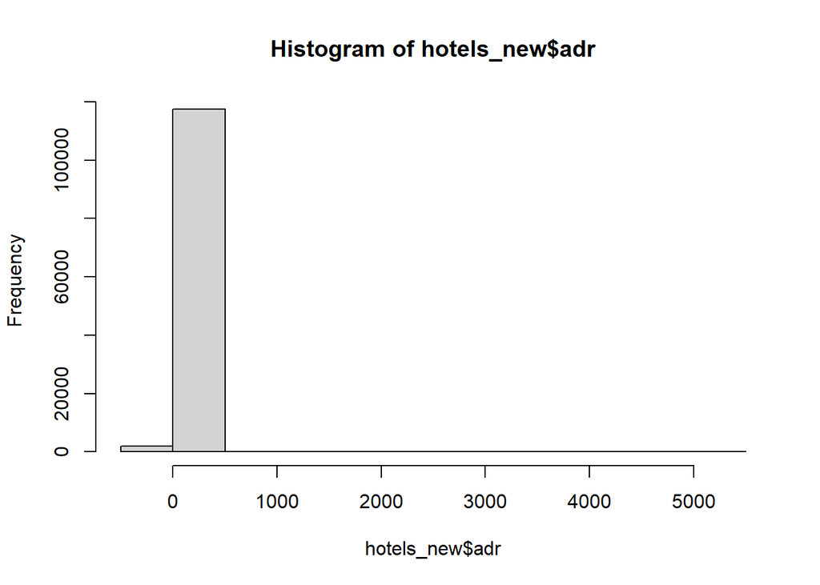

```r
hist(hotels_new$adr)
```

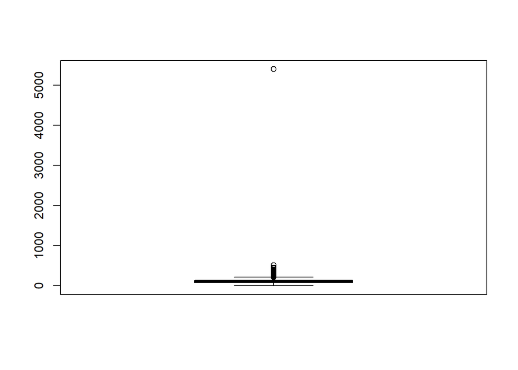

```r
boxplot(hotels_new$adr)
```

The outlier in adr was identified.

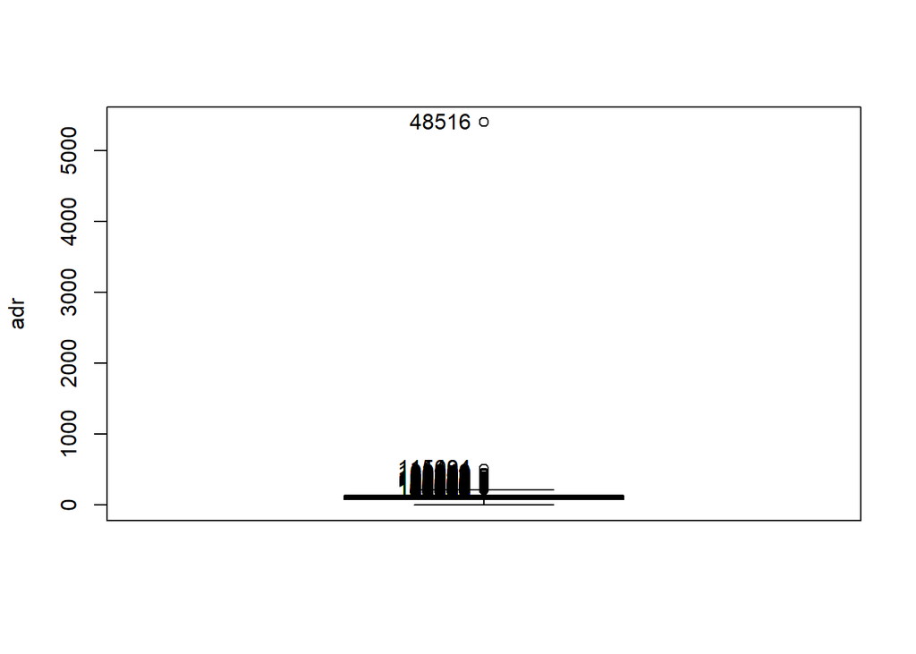

```r
Boxplot(~adr, data=hotels_new, id=list(n=Inf))
```

The outlier was replaced by NA and below is new boxplot without the outlier.

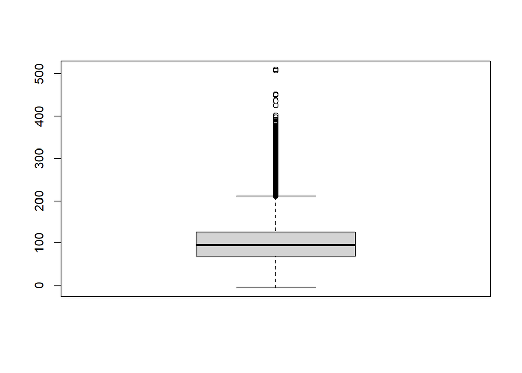

```r
hotels_new[48516, 28] <- NA # row num.  is 48516; column num. for adr is 28
boxplot(hotels_new$adr)
```

#### Final data and Numerical Summary

Below is the table of variable description.

```r
hotels_var_names <- colnames(hotels_new)
hotels_var_type <- lapply(hotels_new, class)
hotels_var_desc <- c("Hotel (City Hotel or Resort Hotel)",
                     "Value indicating if the booking was canceled (1) or not (0)",
                     "Number of days that elapsed between the entering date of the booking into the PMS and the arrival date",
                     "Year of arrival date",
                     "Month of arrival date",
                     "Week number of year for arrival date",
                     "Day of arrival date",
                     "Number of weekend nights (Saturday or Sunday) the guest stayed or booked to stay at the hotel",
                     "Number of week nights (Monday to Friday) the guest stayed or booked to stay at the hotel",
                     "Number of adults",
                     "Number of children",
                     "Number of babies",
                     "Type of meal booked. SC - no meal package; BB - Bed & Breakfast; HB - Half board (breakfast and one other meal – usually dinner); FB - Full board (breakfast, lunch and dinner)",
                     "Country of origin. Categories are represented in the ISO 3155–3:2013 format",
                     "Market segment designation. In categories, the term “TA” means “Travel Agents” and “TO” means “Tour Operators”",
                     "Booking distribution channel. The term “TA” means “Travel Agents” and “TO” means “Tour Operators”",
                     "Value indicating if the booking name was from a repeated guest (1) or not (0)",
                     "Number of previous bookings that were cancelled by the customer prior to the current booking",
                     "Number of previous bookings not cancelled by the customer prior to the current booking",
                     "Code of room type reserved. Code is presented instead of designation for anonymity reasons",
                     "Code for the type of room assigned to the booking. Sometimes the assigned room type differs from the reserved room type due to hotel operation reasons (e.g. overbooking) or by customer request. Code is presented instead of designation for anonymity reasons",
                     "Number of changes/amendments made to the booking from the moment the booking was entered on the PMS until the moment of check-in or cancellation",
                     "Indication on if the customer made a deposit to guarantee the booking. This variable can assume three categories: No Deposit – no deposit was made; Non Refund – a deposit was made in the value of the total stay cost; Refundable – a deposit was made with a value under the total cost of stay.",
                     "ID of the travel agency that made the booking",
                     "ID of the company/entity that made the booking or responsible for paying the booking. ID is presented instead of designation for anonymity reasons",
                     "Number of days the booking was in the waiting list before it was confirmed to the customer",
                     "Type of booking,  assuming one of four categories: Contract - when the booking has an allotment or other type of contract associated to it; Group – when the booking is associated to a group; Transient – when the booking is not part of a group or contract, and is not associated to other transient booking; Transient-party – when the booking is transient, but is associated to at least other transient booking",
                     "Average Daily Rate as defined by dividing the sum of all lodging transactions by the total number of staying nights",
                     "Number of car parking spaces required by the customer",
                     "Number of special requests made by the customer (e.g. twin bed or high floor)",
                     "Reservation last status, assuming one of three categories: Canceled – booking was canceled by the customer; Check-Out – customer has checked in but already departed; No-Show – customer did not check-in and did inform the hotel of the reason why",
                     "Date at which the last status was set. This variable can be used in conjunction with the ReservationStatus to understand when was the booking canceled or when did the customer checked-out of the hotel",
                     "Arrival Date",
                     "Stays in nights"
)

data_desc_df <- as_data_frame(cbind(hotels_var_names, hotels_var_type, hotels_var_desc))
colnames(data_desc_df) <-c("Variable", "Type", "Description")
kable(data_desc_df)
```

| Variable | Type | Description |
| --- | --- | --- |
| hotel | character | Hotel (City Hotel or Resort Hotel) |
| is_canceled | factor | Value indicating if the booking was canceled (1) or not (0) |
| lead_time | integer | Number of days that elapsed between the entering date of the booking into the PMS and the arrival date |
| arrival_date_year | factor | Year of arrival date |
| arrival_date_month | character | Month of arrival date |
| arrival_date_week_number | factor | Week number of year for arrival date |
| arrival_date_day_of_month | factor | Day of arrival date |
| stays_in_weekend_nights | integer | Number of weekend nights (Saturday or Sunday) the guest stayed or booked to stay at the hotel |
| stays_in_week_nights | integer | Number of week nights (Monday to Friday) the guest stayed or booked to stay at the hotel |
| adults | integer | Number of adults |
| children | numeric | Number of children |
| babies | integer | Number of babies |
| meal | character | Type of meal booked. SC - no meal package; BB - Bed & Breakfast; HB - Half board (breakfast and one other meal – usually dinner); FB - Full board (breakfast, lunch and dinner) |
| country | character | Country of origin. Categories are represented in the ISO 3155–3:2013 format |
| market_segment | character | Market segment designation. In categories, the term “TA” means “Travel Agents” and “TO” means “Tour Operators” |
| distribution_channel | character | Booking distribution channel. The term “TA” means “Travel Agents” and “TO” means “Tour Operators” |
| is_repeated_guest | factor | Value indicating if the booking name was from a repeated guest (1) or not (0) |
| previous_cancellations | factor | Number of previous bookings that were cancelled by the customer prior to the current booking |
| previous_bookings_not_canceled | factor | Number of previous bookings not cancelled by the customer prior to the current booking |
| reserved_room_type | character | Code of room type reserved. Code is presented instead of designation for anonymity reasons |
| assigned_room_type | character | Code for the type of room assigned to the booking. Sometimes the assigned room type differs from the reserved room type due to hotel operation reasons (e.g. overbooking) or by customer request. Code i… |
| booking_changes | factor | Number of changes/amendments made to the booking from the moment the booking was entered on the PMS until the moment of check-in or cancellation |
| deposit_type | character | Indication on if the customer made a deposit to guarantee the booking. This variable can assume three categories: No Deposit – no deposit was made; Non Refund – a deposit was made in the value of the … |
| agent | character | ID of the travel agency that made the booking |
| company | character | ID of the company/entity that made the booking or responsible for paying the booking. ID is presented instead of designation for anonymity reasons |
| days_in_waiting_list | integer | Number of days the booking was in the waiting list before it was confirmed to the customer |
| customer_type | character | Type of booking, assuming one of four categories: Contract - when the booking has an allotment or other type of contract associated to it; Group – when the booking is associated to a group; Transient … |
| adr | numeric | Average Daily Rate as defined by dividing the sum of all lodging transactions by the total number of staying nights |
| required_car_parking_spaces | integer | Number of car parking spaces required by the customer |
| total_of_special_requests | integer | Number of special requests made by the customer (e.g. twin bed or high floor) |
| reservation_status | character | Reservation last status, assuming one of three categories: Canceled – booking was canceled by the customer; Check-Out – customer has checked in but already departed; No-Show – customer did not check-i… |
| reservation_status_date | character | Date at which the last status was set. This variable can be used in conjunction with the ReservationStatus to understand when was the booking canceled or when did the customer checked-out of the hotel |
| arrival_date | character | Arrival Date |
| stays_nights | integer | Stays in nights |

Below is the numerical summary for all variables in hotel_new.

```r
hotels_new %>% summary()
```

```
##     hotel           is_canceled   lead_time   arrival_date_year
##  Length:119390      0:75166     Min.   :  0   2015:21996
##  Class :character   1:44224     1st Qu.: 18   2016:56707
##  Mode  :character               Median : 69   2017:40687
##                                 Mean   :104
##                                 3rd Qu.:160
##                                 Max.   :737
##
##  arrival_date_month arrival_date_week_number arrival_date_day_of_month
##  Length:119390      33     :  3580           17     : 4406
##  Class :character   30     :  3087           5      : 4317
##  Mode  :character   32     :  3045           15     : 4196
##                     34     :  3040           25     : 4160
##                     18     :  2926           26     : 4147
##                     21     :  2854           9      : 4096
##                     (Other):100858           (Other):94068
##  stays_in_weekend_nights stays_in_week_nights     adults
##  Min.   : 0.0000         Min.   : 0.0         Min.   : 0.000
##  1st Qu.: 0.0000         1st Qu.: 1.0         1st Qu.: 2.000
##  Median : 1.0000         Median : 2.0         Median : 2.000
##  Mean   : 0.9276         Mean   : 2.5         Mean   : 1.856
##  3rd Qu.: 2.0000         3rd Qu.: 3.0         3rd Qu.: 2.000
##  Max.   :19.0000         Max.   :50.0         Max.   :55.000
##
##     children           babies              meal             country
##  Min.   : 0.0000   Min.   : 0.000000   Length:119390      Length:119390
##  1st Qu.: 0.0000   1st Qu.: 0.000000   Class :character   Class :character
##  Median : 0.0000   Median : 0.000000   Mode  :character   Mode  :character
##  Mean   : 0.1039   Mean   : 0.007949
##  3rd Qu.: 0.0000   3rd Qu.: 0.000000
##  Max.   :10.0000   Max.   :10.000000
##
##  market_segment     distribution_channel is_repeated_guest
##  Length:119390      Length:119390        0:115580
##  Class :character   Class :character     1:  3810
##  Mode  :character   Mode  :character
##
##
##
##
```

[output cut: 25 more lines]

```
##  Min.   :0.00000             Min.   :0.0000            Length:119390
##  1st Qu.:0.00000             1st Qu.:0.0000            Class :character
##  Median :0.00000             Median :0.0000            Mode  :character
##  Mean   :0.06252             Mean   :0.5714
##  3rd Qu.:0.00000             3rd Qu.:1.0000
##  Max.   :8.00000             Max.   :5.0000
##
##  reservation_status_date arrival_date        stays_nights
##  Length:119390           Length:119390      Min.   : 0.000
##  Class :character        Class :character   1st Qu.: 2.000
##  Mode  :character        Mode  :character   Median : 3.000
##                                             Mean   : 3.428
##                                             3rd Qu.: 4.000
##                                             Max.   :69.000
##
```

### Exploratory Data Analysis

Below are the multiple histograms of numeric columns.

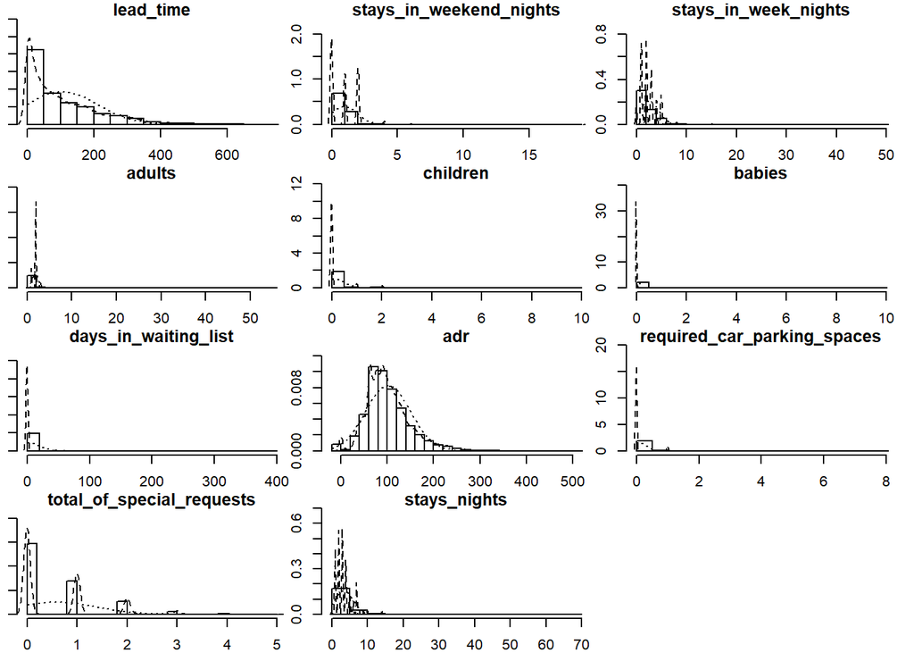

```r
# Plot histograms of numeric columns
multi.hist(hotels_new[,sapply(hotels_new, is.numeric)])
```

The canceled and not canceled groups were displayed for the two hotels.

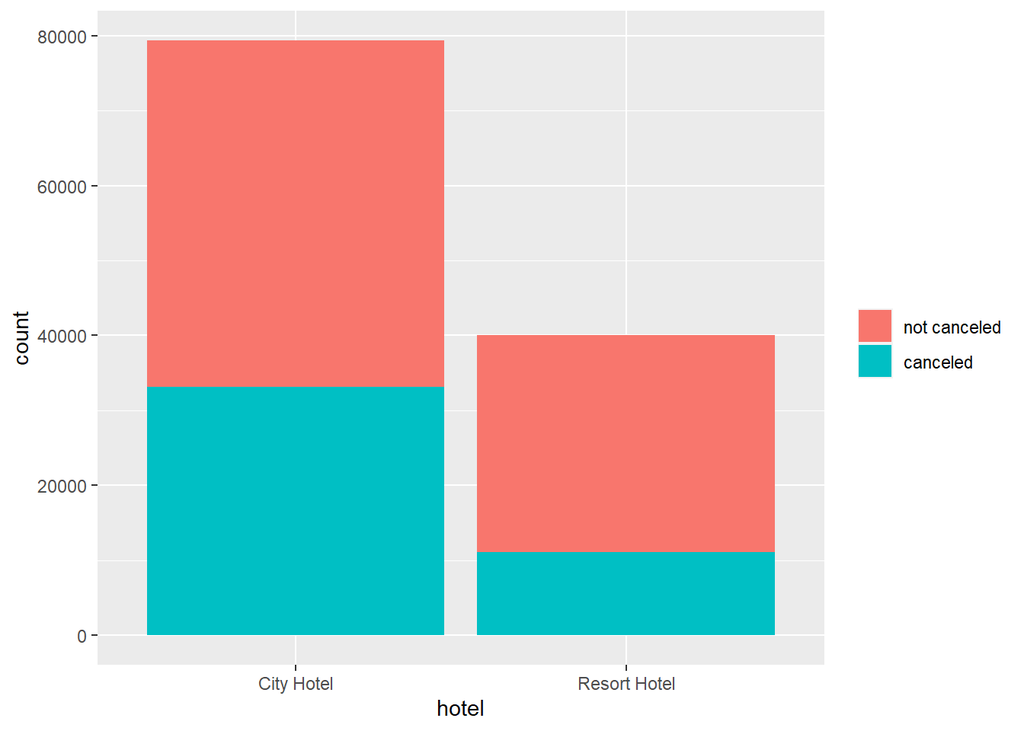

```r
# hotel and cancellation
hotels_new %>% ggplot( aes(x=hotel,
                           fill=is_canceled)) + geom_bar() +
                      scale_fill_discrete(labels=c("not canceled", "canceled")) +
                     guides(fill=guide_legend(title=NULL))
```

Within each customer_type, the canceled and not canceled groups were displayed for the two hotels.

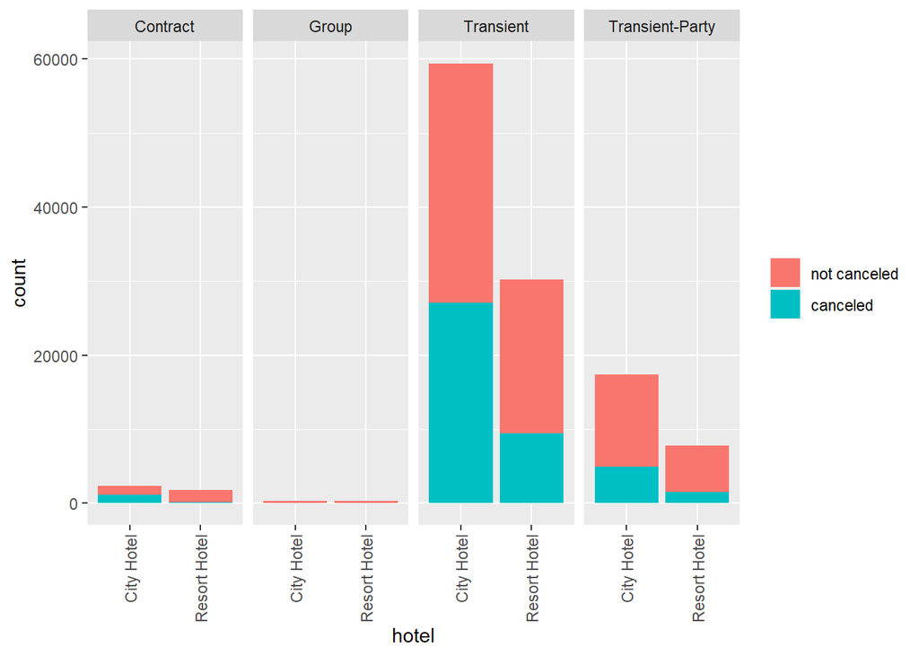

```r
# hotel and cancellation - facet: customer_type
hotels_new %>% ggplot( aes(x=hotel,
                           fill=is_canceled)) + geom_bar() +
  scale_fill_discrete(labels=c("not canceled", "canceled")) +
  guides(fill=guide_legend(title=NULL)) +
  facet_grid(. ~ customer_type) +
  theme(axis.text.x=element_text(angle=90, hjust=1, vjust=0.5))
```

Within each deposit_type, the canceled and not canceled groups were displayed for the two hotels.

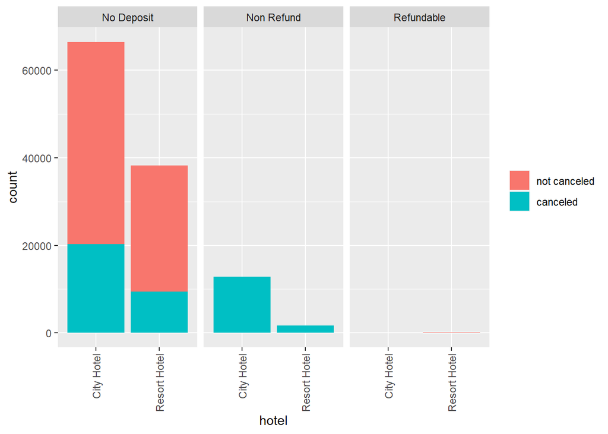

```r
# hotel and cancellation - facet: deposit_type
hotels_new %>% ggplot( aes(x=hotel,
                           fill=is_canceled)) + geom_bar() +
  scale_fill_discrete(labels=c("not canceled", "canceled")) +
  guides(fill=guide_legend(title=NULL)) +
  facet_grid(. ~ deposit_type) +
  theme(axis.text.x=element_text(angle=90, hjust=1, vjust=0.5))
```

Within each market_segment, the canceled and not canceled groups were displayed for the two hotels.

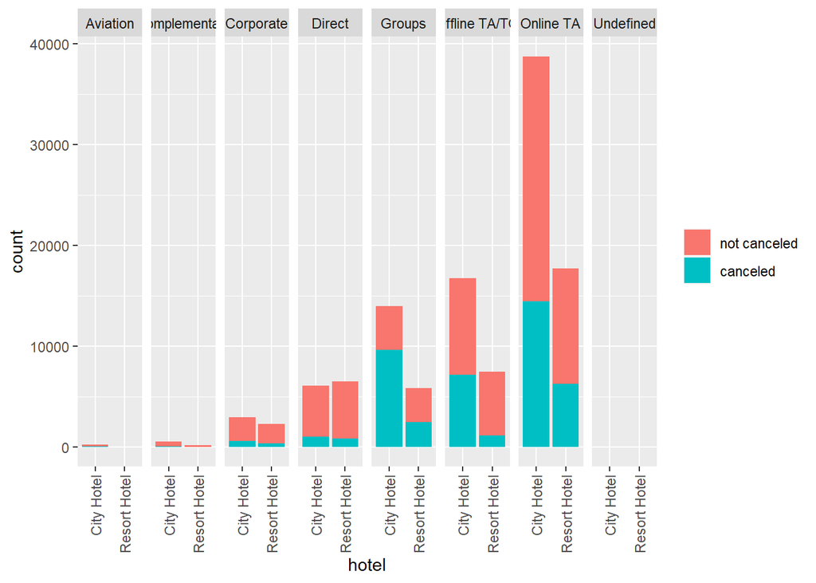

```r
# hotel and cancellation - facet: market_segment
hotels_new %>% ggplot(aes(x=hotel,
                           fill=is_canceled)) + geom_bar() +
  scale_fill_discrete(labels=c("not canceled", "canceled")) +
  guides(fill=guide_legend(title=NULL)) +
  facet_grid(. ~ market_segment) +
  theme(axis.text.x=element_text(angle=90, hjust=1, vjust=0.5))
```

Monthly lead_time were displayed for the canceled and not canceled groups.

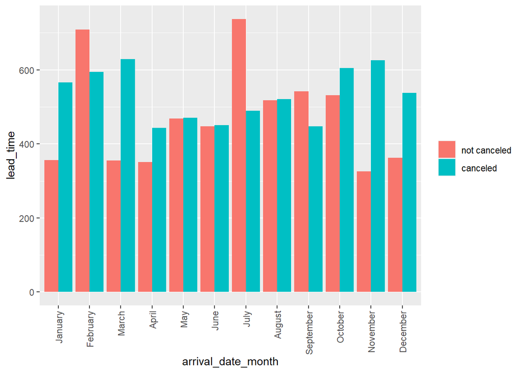

```r
#Lead_time for canceled and not canceled group
hotels_new$arrival_date_month<- factor(hotels_new$arrival_date_month, levels =
                                         c("January", "February", "March", "April", "May", "June", "July", "August", "September", "October", "November", "December"))


hotels_new %>% ggplot( aes(x=arrival_date_month,
                           y=lead_time, fill=is_canceled))+
  geom_bar(stat="identity", position="dodge") +
  scale_fill_discrete(labels=c("not canceled", "canceled")) +
  guides(fill=guide_legend(title=NULL)) +
  theme(axis.text.x=element_text(angle=90, hjust=1, vjust=0.5))
```

Below are scatter plots between two numerical variables.

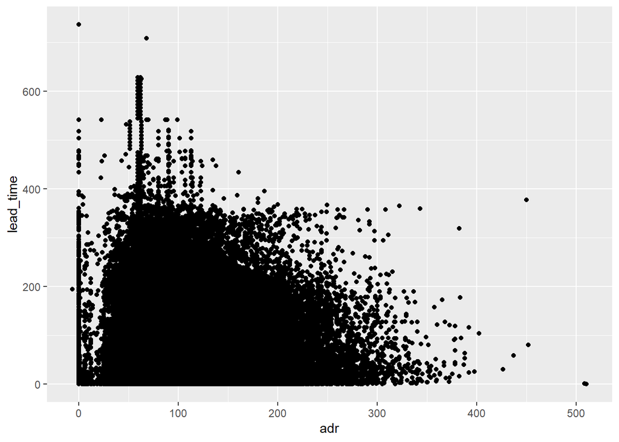

```r
# scatter plot between adr and lead_time
hotels_new %>% ggplot(aes(x=adr, y=lead_time)) +geom_point()
```

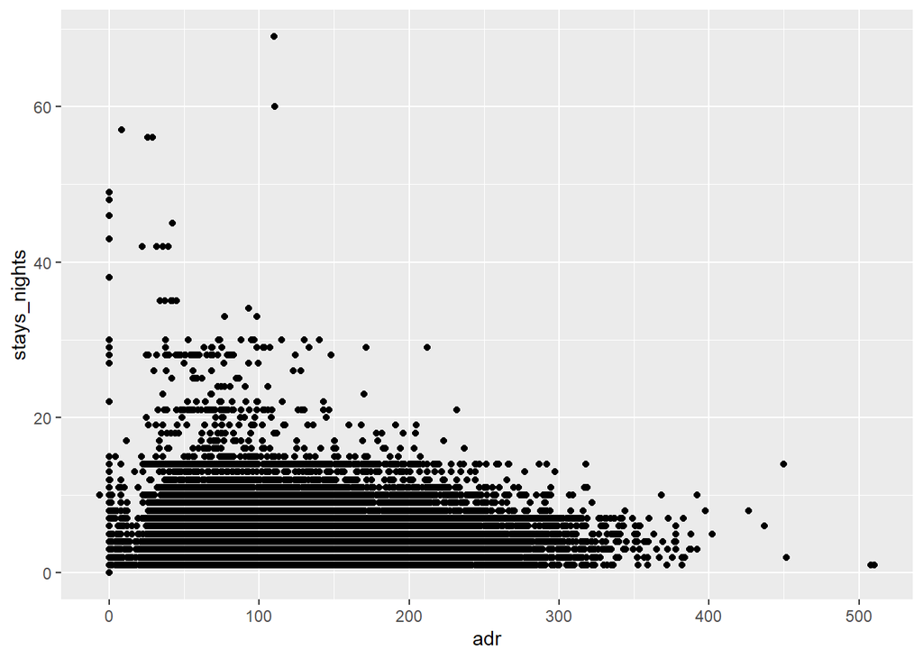

```r
# scatter plot between adr and stays_nights
hotels_new %>% ggplot(aes(x=adr, y=stays_nights)) +geom_point()
```